# practical_exercise_2, Methods 3, 2021, autumn semester

Jørgen Højlund Wibe

September 29 2021

# Assignment 1: Using mixed effects modelling to model hierarchical data

In this assignment we will be investigating the *politeness* dataset of Winter and Grawunder (2012) and apply basic methods of multilevel modelling.

## Dataset

The dataset has been shared on GitHub, so make sure that the csv-file is on your current path. Otherwise you can supply the full path.

```r
politeness <- read.csv('politeness.csv') ## read in data
```

# Exercises and objectives

The objectives of the exercises of this assignment are:  
1) Learning to recognize hierarchical structures within datasets and describing them  
2) Creating simple multilevel models and assessing their fitness  
3) Write up a report about the findings of the study

REMEMBER: In your report, make sure to include code that can reproduce the answers requested in the exercises below  
*REMEMBER: This assignment will be part of your final portfolio*

## Exercise 1 - describing the dataset and making some initial plots

1. Describe the dataset, such that someone who happened upon this dataset could understand the variables and what they contain
   1. Also consider whether any of the variables in *politeness* should be encoded as factors or have the factor encoding removed.

### Description of dataset

The following exercise will investigate the ‘politeness dataset’ from a study by Grawunder and Winter (2012). The study investigates the relationship between the pitch (i.e., frequency) of a voice and the politeness in the Korean formal and informal speech.

The following are the variables involved in the study: *subject*: Participants involved in the experiment *gender*: Sex is represented as “F” and “M” *scenario*: *attitude*: The attitude of the message, to which the participants had to respond: Either informal (inf) or polite (pol). *total_duration*: Duration of each response *f0mn*: Pitch response: Measured as a mean pitch in Herz over the different utterances. *hiss_count*: Unexpectedly, formality also affected breathing patterns, leading to a noticeable increase in the amount of loud ‘‘hissing’’ breath intakes in formal speech.

The gender and attitude variables are interpreted as characters by R. To make the models more interpretable it is preferable to recode the classes to factor:

```r
# Preparing data
politeness$gender <- as.factor(politeness$gender)
politeness$attitude <- as.factor(politeness$attitude)
```

2. Create a new data frame that just contains the subject *F1* and 2.1 run two linear models; 2.2.1 one that expresses *f0mn* as dependent on *scenario* as an integer; and 2.2.2. one that expresses *f0mn* as dependent on *scenario* encoded as a factor
   1. Include the model matrices, $X$ from the General Linear Model, for these two models in your report and describe the different interpretations of *scenario* that these entail
   2. Which coding of *scenario*, as a factor or not, is more fitting?

```r
# Creating a new df, only containing data on subject F1
politeness_F1 <- politeness %>%
  filter(subject == "F1")

# Linear model 1
mod_1 <- lm(f0mn ~ scenario, data = politeness_F1)
summary(mod_1)
```

```
##
## Call:
## lm(formula = f0mn ~ scenario, data = politeness_F1)
##
## Residuals:
##     Min      1Q  Median      3Q     Max
## -44.836 -36.807   6.686  20.918  46.421
##
## Coefficients:
##             Estimate Std. Error t value Pr(>|t|)
## (Intercept)  262.621     20.616  12.738 2.48e-08 ***
## scenario      -6.886      4.610  -1.494    0.161
## ---
## Signif. codes:  0 '***' 0.001 '**' 0.01 '*' 0.05 '.' 0.1 ' ' 1
##
## Residual standard error: 34.5 on 12 degrees of freedom
## Multiple R-squared:  0.1568, Adjusted R-squared:  0.0865
## F-statistic: 2.231 on 1 and 12 DF,  p-value: 0.1611
```

```r
## Printing design matrix for model 1
model.matrix(mod_1)
```

```
##    (Intercept) scenario
## 1            1        1
## 2            1        1
## 3            1        2
## 4            1        2
## 5            1        3
## 6            1        3
## 7            1        4
## 8            1        4
## 9            1        5
## 10           1        5
## 11           1        6
## 12           1        6
## 13           1        7
## 14           1        7
## attr(,"assign")
## [1] 0 1
```

```r
# Linear model 2
## Converting scenario to a factor
politeness_F1$scenario_as.f <- as.factor(politeness_F1$scenario)

mod_2 <- lm(f0mn ~ scenario_as.f, data = politeness_F1)
summary(mod_2)
```

```
##
## Call:
## lm(formula = f0mn ~ scenario_as.f, data = politeness_F1)
##
## Residuals:
##    Min     1Q Median     3Q    Max
## -37.50 -13.86   0.00  13.86  37.50
##
## Coefficients:
##                Estimate Std. Error t value Pr(>|t|)
## (Intercept)      212.75      20.35  10.453  1.6e-05 ***
## scenario_as.f2    62.40      28.78   2.168   0.0668 .
## scenario_as.f3    35.35      28.78   1.228   0.2591
## scenario_as.f4    53.75      28.78   1.867   0.1041
## scenario_as.f5    27.30      28.78   0.948   0.3745
## scenario_as.f6    -7.55      28.78  -0.262   0.8006
## scenario_as.f7   -14.95      28.78  -0.519   0.6195
## ---
## Signif. codes:  0 '***' 0.001 '**' 0.01 '*' 0.05 '.' 0.1 ' ' 1
##
## Residual standard error: 28.78 on 7 degrees of freedom
## Multiple R-squared:  0.6576, Adjusted R-squared:  0.364
## F-statistic:  2.24 on 6 and 7 DF,  p-value: 0.1576
```

```r
## Printing design matrix for model 2
model.matrix(mod_2)
```

```
##    (Intercept) scenario_as.f2 scenario_as.f3 scenario_as.f4 scenario_as.f5
## 1            1              0              0              0              0
## 2            1              0              0              0              0
## 3            1              1              0              0              0
## 4            1              1              0              0              0
## 5            1              0              1              0              0
## 6            1              0              1              0              0
## 7            1              0              0              1              0
## 8            1              0              0              1              0
## 9            1              0              0              0              1
## 10           1              0              0              0              1
## 11           1              0              0              0              0
## 12           1              0              0              0              0
## 13           1              0              0              0              0
## 14           1              0              0              0              0
```

[output cut: 20 more lines]

*Explanation* The model matrix from mod_1 is problematic in regards to a linear regression, since all the values are weighted hierachical which we are not interested in. When looking at the model matrix from mod_2, we account for this we make the different scenarios into flag variables to make sure they are all equally weighted.

3. Make a plot that includes a subplot for each subject that has *scenario* on the x-axis and *f0mn* on the y-axis and where points are colour coded according to *attitude*
   1. Describe the differences between subjects

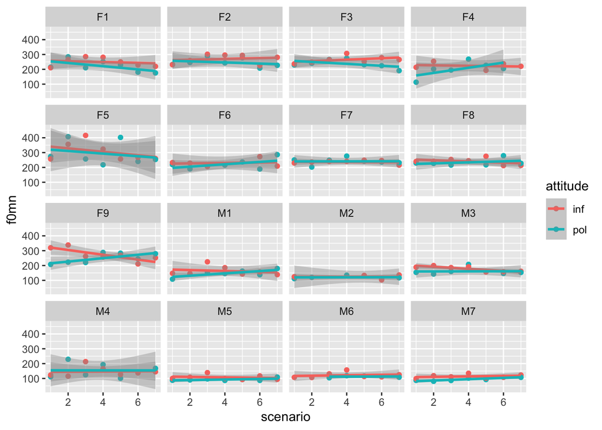

```r
# Plot
ggplot(politeness, aes(scenario, f0mn, color = attitude))+
  geom_point()+
  facet_wrap(~subject)+
  geom_smooth(method = lm)
```

One obvious difference between subjects are the general difference in level of pitch between males and females. Females pitch are higher. To statistically test this difference we would have to run a t-test, but due to the scope of this assignment, we will leave it be.

## Exercise 2 - comparison of models

1. Build four models and do some comparisons
   1. a single level model that models *f0mn* as dependent on *gender*
   2. a two-level model that adds a second level on top of i. where unique intercepts are modelled for each *scenario*
   3. a two-level model that only has *subject* as an intercept
   4. a two-level model that models intercepts for both *scenario* and *subject*

*Building models*

```r
# Model 1
model1 <- lm(f0mn ~ gender, data = politeness)
summary(model1)
```

```
##
## Call:
## lm(formula = f0mn ~ gender, data = politeness)
##
## Residuals:
##      Min       1Q   Median       3Q      Max
## -134.283  -24.928   -6.783   20.517  168.217
##
## Coefficients:
##             Estimate Std. Error t value Pr(>|t|)
## (Intercept)  247.583      3.588   69.01   <2e-16 ***
## genderM     -115.821      5.476  -21.15   <2e-16 ***
## ---
## Signif. codes:  0 '***' 0.001 '**' 0.01 '*' 0.05 '.' 0.1 ' ' 1
##
## Residual standard error: 39.46 on 210 degrees of freedom
##   (12 observations deleted due to missingness)
## Multiple R-squared:  0.6806, Adjusted R-squared:  0.679
## F-statistic: 447.4 on 1 and 210 DF,  p-value: < 2.2e-16
```

```r
# Model 2
model2 <- lmer(f0mn ~ gender + (1 | scenario), data = politeness)
summary(model2)
```

```
## Linear mixed model fit by REML ['lmerMod']
## Formula: f0mn ~ gender + (1 | scenario)
##    Data: politeness
##
## REML criterion at convergence: 2144.3
##
## Scaled residuals:
##     Min      1Q  Median      3Q     Max
## -3.2314 -0.6033 -0.1599  0.4893  4.2069
##
## Random effects:
##  Groups   Name        Variance Std.Dev.
##  scenario (Intercept)   91.77   9.579
##  Residual             1478.25  38.448
## Number of obs: 212, groups:  scenario, 7
##
## Fixed effects:
##             Estimate Std. Error t value
## (Intercept)  247.786      5.033   49.23
## genderM     -115.875      5.338  -21.71
##
## Correlation of Fixed Effects:
##         (Intr)
## genderM -0.455
```

```r
# Model 3
model3 <- lmer(f0mn ~ gender + (1 | subject), data = politeness)
summary(model3)
```

```
## Linear mixed model fit by REML ['lmerMod']
## Formula: f0mn ~ gender + (1 | subject)
##    Data: politeness
##
## REML criterion at convergence: 2091.6
##
## Scaled residuals:
##     Min      1Q  Median      3Q     Max
## -3.2200 -0.5402 -0.1385  0.4358  3.8184
##
## Random effects:
##  Groups   Name        Variance Std.Dev.
##  subject  (Intercept)  595.1   24.39
##  Residual             1026.7   32.04
## Number of obs: 212, groups:  subject, 16
##
## Fixed effects:
##             Estimate Std. Error t value
## (Intercept)  246.525      8.641  28.531
## genderM     -115.181     13.080  -8.806
##
## Correlation of Fixed Effects:
##         (Intr)
## genderM -0.661
```

```r
# Model 4
model4 <- lmer(f0mn ~ gender + (1 | subject) + (1 | scenario), data = politeness)
summary(model4)
```

```
## Linear mixed model fit by REML ['lmerMod']
## Formula: f0mn ~ gender + (1 | subject) + (1 | scenario)
##    Data: politeness
##
## REML criterion at convergence: 2082.5
##
## Scaled residuals:
##     Min      1Q  Median      3Q     Max
## -3.0131 -0.5373 -0.1089  0.4381  3.7558
##
## Random effects:
##  Groups   Name        Variance Std.Dev.
##  subject  (Intercept) 588.83   24.266
##  scenario (Intercept)  96.17    9.807
##  Residual             939.92   30.658
## Number of obs: 212, groups:  subject, 16; scenario, 7
##
## Fixed effects:
##             Estimate Std. Error t value
## (Intercept)  246.765      9.327   26.46
## genderM     -115.175     12.955   -8.89
##
## Correlation of Fixed Effects:
##         (Intr)
## genderM -0.606
```

22. which of the models has the lowest residual standard deviation, also compare the Akaike Information Criterion `AIC`?
6. which of the second-level effects explains the most variance?

Comparing models

```r
# Residual standard deviation of models (shown in a tibble)
ResStdDev_all <- tibble(sigma_model1 = sigma(model1),
                        sigma_model2=sigma(model2),
                        sigma_model3=sigma(model3),
                        sigma_model4=sigma(model4))
ResStdDev_all
```

| sigma_model1 | sigma_model2 | sigma_model3 | sigma_model4 |
| --- | --- | --- | --- |
| 39.46268 | 38.448 | 32.04287 | 30.65803 |

```r
# AIC values (also shown in a tibble)
AIC_values <- tibble(AIC(model1),
                     AIC(model2),
                     AIC(model3),
                     AIC(model4))
AIC_values
```

| AIC(model1) | AIC(model2) | AIC(model3) | AIC(model4) |
| --- | --- | --- | --- |
| 2163.971 | 2152.314 | 2099.626 | 2092.482 |

```r
# Putting values in a df for better overview
AIC_Sigma <- tribble(
  ~ model, ~sigma_values, ~AIC_values,
  "model1", sigma(model1), AIC(model1),
  "model2", sigma(model2), AIC(model2),
  "model3", sigma(model3), AIC(model3),
  "model4", sigma(model4), AIC(model4)
)
AIC_Sigma
```

| model | sigma_values | AIC_values |
| --- | --- | --- |
| model1 | 39.46268 | 2163.971 |
| model2 | 38.44800 | 2152.314 |
| model3 | 32.04287 | 2099.626 |
| model4 | 30.65803 | 2092.482 |

```r
# which of the 2nd level models explains the most variance
MuMIn::r.squaredGLMM(model2) #R2c = 0.6967788
```

```
##            R2m       R2c
## [1,] 0.6779555 0.6967788
```

```r
MuMIn::r.squaredGLMM(model3) #R2c = 0.7899229
```

```
##            R2m       R2c
## [1,] 0.6681651 0.7899229
```

*Explanation*: When comparing only the second-levels effects (model 2 and model 3) by their Conditional R2 (R2c) which states how much variance is explained by both random and fixed effects, it is shown that model 2 has an R2c of 0.6967788 and model 3 has an R2c of 0.7899229, and thus stating that the second-level effect “subject” explains the most variance.

2. Why is our single-level model bad? # too simple and doesn’t have different baselines for N’s and condition.
   1. create a new data frame that has three variables, *subject*, *gender* and *f0mn*, where *f0mn* is the average of all responses of each subject, i.e. averaging across *attitude* and_scenario_
   2. build a single-level model that models *f0mn* as dependent on *gender* using this new dataset
   3. make Quantile-Quantile plots, comparing theoretical quantiles to the sample quantiles) using `qqnorm` and `qqline` for the new single-level model and compare it to the old single-level model (from 1).i). Which model’s residuals ($\epsilon$) fulfil the assumptions of the General Linear Model better?
   4. Also make a quantile-quantile plot for the residuals of the multilevel model with two intercepts. Does it look alright?

```r
# Creating df
politeness_new <- politeness %>%
  select(subject, gender, f0mn) %>%
  group_by(subject) %>%
  mutate(f0mn = mean(f0mn))

# Modelling
model_1 <- lm(f0mn ~ gender, data = politeness_new)
summary(model_1)
```

```
##
## Call:
## lm(formula = f0mn ~ gender, data = politeness_new)
##
## Residuals:
##     Min      1Q  Median      3Q     Max
## -32.050 -19.308  -3.394  22.893  44.842
##
## Coefficients:
##             Estimate Std. Error t value Pr(>|t|)
## (Intercept)  254.387      2.501  101.71   <2e-16 ***
## genderM     -122.237      4.148  -29.47   <2e-16 ***
## ---
## Signif. codes:  0 '***' 0.001 '**' 0.01 '*' 0.05 '.' 0.1 ' ' 1
##
## Residual standard error: 24.76 on 152 degrees of freedom
##   (70 observations deleted due to missingness)
## Multiple R-squared:  0.8511, Adjusted R-squared:  0.8501
## F-statistic: 868.6 on 1 and 152 DF,  p-value: < 2.2e-16
```

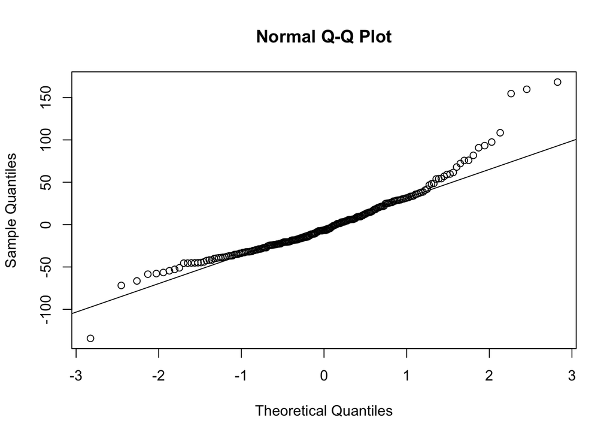

```r
# QQ plot (3)
## qq-plot of single-level-model
qqnorm(resid(model1))
qqline(resid(model1))
```

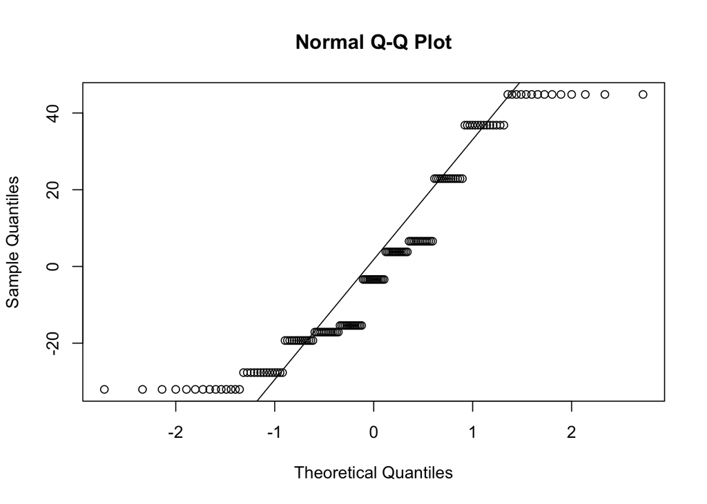

```r
## qq-plot of model 1
qqnorm(resid(model_1))
qqline(resid(model_1))
```

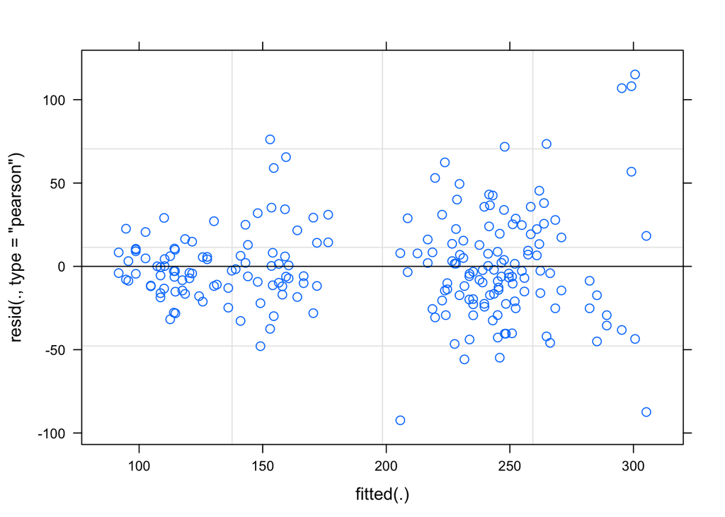

```r
#   iv. Also make a quantile-quantile plot for the residuals of the  multilevel model with two intercepts. Does it look alright?
#   residual plot
plot(model4)
```

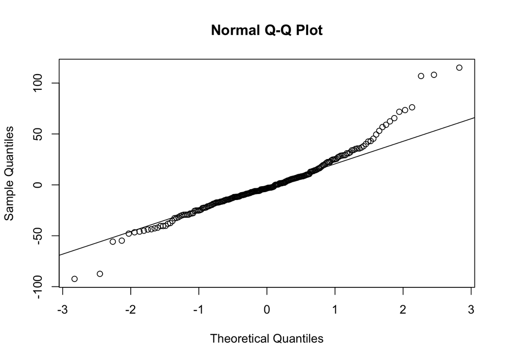

```r
## qq-plot of single-level-model
qqnorm(resid(model4))
qqline(resid(model4))
```

3. Plotting the two-intercepts model
   1. Create a plot for each subject, (similar to part 3 in Exercise 1), this time also indicating the fitted value *for each of the subjects for each for the scenarios* (hint use `fixef` to get the “grand effects” for each gender and `ranef` to get the subject- and scenario-specific effects)

```r
# Replacing NA with mean of subjects f0mn
politeness <- politeness %>%
  group_by(subject) %>%
  mutate(f0mn = ifelse(is.na(f0mn), mean(f0mn, na.rm = TRUE), f0mn))

model4 <- lmer(f0mn ~ gender + (1 | subject) + (1 | scenario), data = politeness)
summary(model4)
```

```
## Linear mixed model fit by REML ['lmerMod']
## Formula: f0mn ~ gender + (1 | subject) + (1 | scenario)
##    Data: politeness
##
## REML criterion at convergence: 2188.8
##
## Scaled residuals:
##     Min      1Q  Median      3Q     Max
## -3.0458 -0.5030 -0.1125  0.4029  3.8668
##
## Random effects:
##  Groups   Name        Variance Std.Dev.
##  subject  (Intercept) 607.40   24.646
##  scenario (Intercept)  81.87    9.048
##  Residual             892.05   29.867
## Number of obs: 224, groups:  subject, 16; scenario, 7
##
## Fixed effects:
##             Estimate Std. Error t value
## (Intercept)  246.370      9.288  26.526
## genderM     -115.092     13.055  -8.816
##
## Correlation of Fixed Effects:
##         (Intr)
## genderM -0.615
```

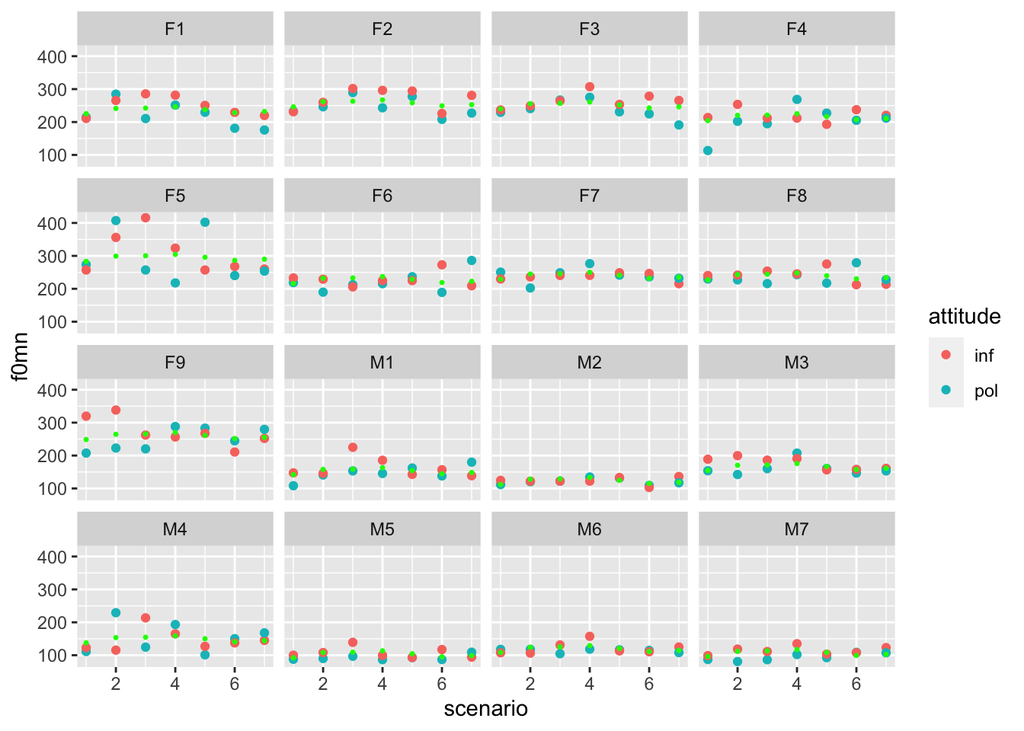

```r
# Plot
politeness$yhat <- predict(model4)

ggplot(politeness, aes(scenario, f0mn, color = attitude))+
  geom_point()+
  geom_point(aes(y = politeness$yhat), color = "green", size = .5)+
  facet_wrap(~subject)
```

## Exercise 3 - now with attitude

1. Carry on with the model with the two unique intercepts fitted (*scenario* and *subject*) (model4)
   1. now build a model that has *attitude* as a main effect besides *gender*
   2. make a separate model that besides the main effects of *attitude* and *gender* also include their interaction
   3. describe what the interaction term in the model says about Korean men’s pitch when they are polite relative to Korean women’s pitch when they are polite (you don’t have to judge whether it is interesting)

```r
# Model with attitude as main effect besides gender
model5 <- lmer(f0mn ~ gender + attitude + (1 | subject) + (1 | scenario), data = politeness)
summary(model5)
```

```
## Linear mixed model fit by REML ['lmerMod']
## Formula: f0mn ~ gender + attitude + (1 | subject) + (1 | scenario)
##    Data: politeness
##
## REML criterion at convergence: 2173.1
##
## Scaled residuals:
##     Min      1Q  Median      3Q     Max
## -2.8861 -0.5948 -0.0981  0.4015  3.9216
##
## Random effects:
##  Groups   Name        Variance Std.Dev.
##  subject  (Intercept) 610.51   24.709
##  scenario (Intercept)  83.23    9.123
##  Residual             848.56   29.130
## Number of obs: 224, groups:  subject, 16; scenario, 7
##
## Fixed effects:
##             Estimate Std. Error t value
## (Intercept)  252.928      9.500  26.624
## genderM     -115.092     13.055  -8.816
## attitudepol  -13.116      3.893  -3.370
##
## Correlation of Fixed Effects:
##             (Intr) gendrM
## genderM     -0.601
## attitudepol -0.205  0.000
```

```r
# ^ Model including interaction
model6 <- lmer(f0mn ~ gender*attitude + (1 | subject) + (1 | scenario), data = politeness)
summary(model6)
```

```
## Linear mixed model fit by REML ['lmerMod']
## Formula: f0mn ~ gender * attitude + (1 | subject) + (1 | scenario)
##    Data: politeness
##
## REML criterion at convergence: 2166.6
##
## Scaled residuals:
##     Min      1Q  Median      3Q     Max
## -2.8399 -0.5643 -0.0944  0.4264  3.9610
##
## Random effects:
##  Groups   Name        Variance Std.Dev.
##  subject  (Intercept) 610.37   24.71
##  scenario (Intercept)  83.17    9.12
##  Residual             850.50   29.16
## Number of obs: 224, groups:  subject, 16; scenario, 7
##
## Fixed effects:
##                     Estimate Std. Error t value
## (Intercept)          254.193      9.654  26.330
## genderM             -117.983     13.633  -8.654
## attitudepol          -15.646      5.196  -3.011
## genderM:attitudepol    5.781      7.856   0.736
##
## Correlation of Fixed Effects:
##             (Intr) gendrM atttdp
## genderM     -0.618
## attitudepol -0.269  0.191
## gndrM:tttdp  0.178 -0.288 -0.661
```

```r
# iii. describe what the interaction term in the model says about Korean men's pitch when they are polite relative to Korean women's pitch when they are polite (you don't have to judge whether it is interesting)
```

2. Compare the three models (1. gender as a main effect; 2. gender and attitude as main effects; 3. gender and attitude as main effects and the interaction between them. For all three models model unique intercepts for *subject* and *scenario*) using residual variance, residual standard deviation and AIC.

```r
# Residual standard deviation of models (shown in a tibble)
ResStdDev_all_2 <- tibble(sigma_model4 = sigma(model4),
                        sigma_model5=sigma(model5),
                        sigma_model6=sigma(model6))

# AIC values
AIC_values <- tibble(AIC(model1),AIC(model2),AIC(model3),AIC(model4))

# Residual variance model 4
RV1 <- (sum((fitted(model4) - politeness$f0mn)^2))/(length(politeness$f0mn)-2) # sum of squared divided by data points minus 2 degrees of freedom.

# Residual variance model 5
RV2 <- (sum((fitted(model5) - politeness$f0mn)^2))/(length(politeness$f0mn)-2)

# Residual variance model 6
RV3 <- (sum((fitted(model6) - politeness$f0mn)^2))/(length(politeness$f0mn)-2)

# Finding r-squared
Rsq1 <- MuMIn::r.squaredGLMM(model4) #R2c = 0.779
Rsq2 <- MuMIn::r.squaredGLMM(model5) #R2c = 0.787
Rsq3 <- MuMIn::r.squaredGLMM(model6) #R2c = 0.787

# For better overview
overview2 <- tribble(
  ~ model, ~sigma, ~AIC_values, ~Residual_variance, ~Rsquared,
  "model4", sigma(model4), AIC(model4), RV1, Rsq1[,2],
  "model5", sigma(model5), AIC(model5), RV2, Rsq2[,2],
  "model6", sigma(model6), AIC(model6), RV3, Rsq3[,2]
)
overview2
```

| model | sigma | AIC_values | Residual_variance | Rsquared |
| --- | --- | --- | --- | --- |
| model4 | 29.86727 | 2198.778 | 823.1541 | 0.8162890 |
| model5 | 29.13006 | 2185.125 | 778.6660 | 0.8253963 |
| model6 | 29.16333 | 2180.623 | 776.6383 | 0.8251343 |

3. Choose the model that you think describe the data the best - and write a short report on the main findings based on this model. At least include the following:
1. describe what the dataset consists of
2. what can you conclude about the effect of gender and attitude on pitch (if anything)?
3. motivate why you would include separate intercepts for subjects and scenarios (if you think they should be included)
4. describe the variance components of the second level (if any)
5. include a Quantile-Quantile plot of your chosen model

I interpret the first question as what the variables in my model consists of: I refer to the first part of the portfolio for more information about the variables.

f0mn ~ gender * attitude + (1 | subject) + (1 | scenario)

It makes sense to include separate intercepts for the variables “subject” and “scenario”, since we then assume that each subject and scenario has different baselines - a different average effect in pitch per subject and scenario. By making separate intercepts, we account for individual differences across subject and scenario.

*QQplot for model 6* Q-plot from model 6, the distribution seem to have a right skewed tail. The residuals of the chosen model (m6) indicated minor violations from normality primarily at the right end of the line.

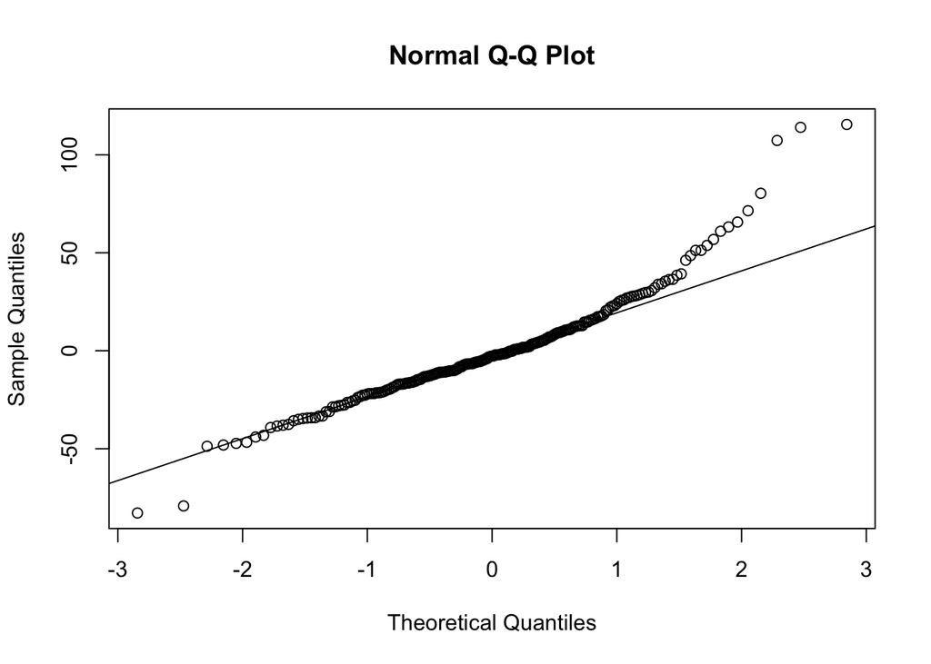

```r
qqnorm(residuals(model6))
qqline(residuals(model6))
```